# 分析y2變數 v1

lin

2020年8月17日

```stata
//use ../data/t15y_de,clear
use ../transfer/work_new_v3,clear


forvalues idx=1/6 {
  tobin y`idx',gen("y`idx'_eqg_me") mean  eqg
  tobin y`idx',gen("y`idx'_g_me") mean  g
  tobin y`idx',gen("y`idx'_eqg_md") p50  eqg
  tobin y`idx',gen("y`idx'_g_md") p50  g
  tobin y`idx',gen("y`idx'_eqg_umd") up50  eqg
  tobin y`idx',gen("y`idx'_g_umd") up50  g
}

  gen y=y1+y2+y3+y4+y5+y6
  tobin y,gen("y_eqg_me") mean  eqg
  tobin y,gen("y_g_me") mean  g
  tobin y,gen("y_eqg_md") p50  eqg
  tobin y,gen("y_g_md") p50  g
  tobin y,gen("y_eqg_umd") up50  eqg
  tobin y,gen("y_g_umd") up50  g

  // 模型Y的輸出 ym1 ym2 to ym6



local idx 1
foreach sep in me md umd{
  foreach opr in eqg g{
    capture safedrop my`idx'
    local ylabel "`=cond("`opr'"=="eqg","大等","大於")'`=cond("`sep'"=="me","平均",cond("`sep'"=="md","中間","獨中間"))'"
    modelbin y1_`opr'_`sep' y2_`opr'_`sep' y3_`opr'_`sep' y4_`opr'_`sep' y5_`opr'_`sep' y6_`opr'_`sep',gen(my`idx') label("`ylabel'")
   disp "`ylabel'"
    local ++idx
  }
}
```

## 統計量

```stata
qui uniqMiddle y2
label variable y2 "日常障礙(反)"
histogram y2, xline(`r(mean)', lcolor(red)) ///
              xline(`r(p50)', lcolor(green)) ///
              xline(`r(up50)', lcolor(black)) ///
              xla(`r(mean)' "mn" `r(p50)' "md" `r(up50)' "umd" `r(mode)' )

  genfilename "$outposix",post(.png) pre("report/") autoinc
    graph export `r(fn)', as(png) replace
```

```
 .
.
. qui uniqMiddle y2

. label variable y2 "日常障礙(反)"

. histogram y2, xline(`r(mean)', lcolor(red)) ///
>               xline(`r(p50)', lcolor(green)) ///
>               xline(`r(up50)', lcolor(black)) ///
>               xla(`r(mean)' "mn" `r(p50)' "md" `r(up50)' "umd" `r(mode)' )
(bin=37, start=0, width=2.7027027)

.
.   genfilename "$outposix",post(.png) pre("report/") autoinc
檔案名稱:report/out_seey2_v1_1.png

.         graph export `r(fn)', as(png) replace
(note: file report/out_seey2_v1_1.png not found)
(file report/out_seey2_v1_1.png written in PNG format)

.
```

圖

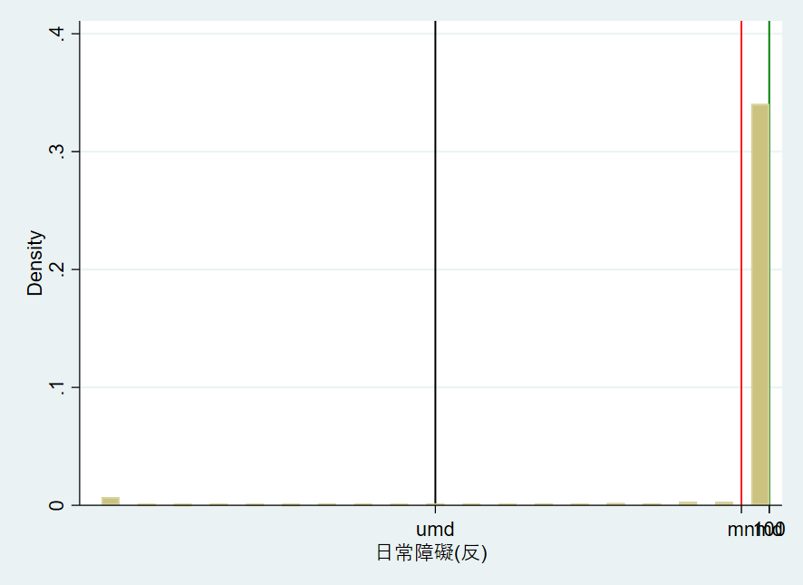

### y2

```stata
sum y2 C16_?,detail
```

```
 . sum y2 C16_?,detail

                      日常障礙(反)
-------------------------------------------------------------
      Percentiles      Smallest
 1%            0              0
 5%     66.66666              0
10%          100              0       Obs               5,304
25%          100              0       Sum of Wgt.       5,304

50%          100                      Mean           95.83019
                        Largest       Std. Dev.      17.31309
75%          100            100
90%          100            100       Variance        299.743
95%          100            100       Skewness      -4.553429
99%          100            100       Kurtosis       23.21953

                            C16_1
-------------------------------------------------------------
      Percentiles      Smallest
 1%            1              1
 5%            1              1
10%            1              1       Obs               5,304
25%            1              1       Sum of Wgt.       5,304

50%            1                      Mean           1.160445
                        Largest       Std. Dev.      .6379863
75%            1              4
90%            1              4       Variance       .4070265
95%            3              4       Skewness       3.961069
99%            4              4       Kurtosis       17.20627

                            C16_2
-------------------------------------------------------------
      Percentiles      Smallest
 1%            1              1
 5%            1              1
10%            1              1       Obs               5,304
25%            1              1       Sum of Wgt.       5,304

```

[output cut: 53 more lines]

```
-------------------------------------------------------------
      Percentiles      Smallest
 1%            1              1
 5%            1              1
10%            1              1       Obs               5,304
25%            1              1       Sum of Wgt.       5,304

50%            1                      Mean           1.123115
                        Largest       Std. Dev.      .5493909
75%            1              4
90%            1              4       Variance       .3018303
95%            2              4       Skewness       4.603709
99%            4              4       Kurtosis       23.14764

.
```

# Y2 VS Y4

👽  
Y4:問卷範圍是C14  
Y2:問卷範圍是C16

💯 考慮一下是不是把Y2,Y4反過來

> 問卷上說: 上面的C14,1到9都沒有問題(也就是0),就跳到C16(但是C16是 **Y2**)

👍👍👍 : 不用了,上面說的跳問,是跳過C15a,b 兩個問題,是不是9項都是0都是要問C16。

## Y4 工具性日常生活活動障礙(IADLs) 負向

C14.在沒有人幫助，也沒有工具輔助下，您獨自做下面的事，就您的健康和身體的情形來看，是不是有困難？  
C14 共1~9

沒困難:0  
有些困難或需工具輔助:1  
很困難或需人幫助:2  
完全做不到:3  
不知道:4  
沒做過:5  
其他無法歸類的答案:7  
不適用:8  
不詳:9

> 問卷上說: 上面的C14(Y4),1到9都沒有問題(也就是0),就跳到C16(Y2),六個子問題。

### 驗證上面的C15

tab2 C14_1 C16_1

```stata
//9項C14都是0,就設定為1,否則為0
capture drop tmp
egen tmp=anycount(C14_?), values(1)
label variable tmp ""
label variable tmp "C14九項都是00(1)"
//在tmp ==1 的時候,C16的部分應該有東西。
replace tmp=cond(tmp==9,1,0)
forvalues idx=1/6{
  tab2 tmp C16_`idx'
}
```

```
 . //9項C14都是0,就設定為1,否則為0
. capture drop tmp

. egen tmp=anycount(C14_?), values(1)

. label variable tmp ""

. label variable tmp "C14九項都是00(1)"

. //在tmp ==1 的時候,C16的部分應該有東西。
. replace tmp=cond(tmp==9,1,0)
(5,071 real changes made)

. forvalues idx=1/6{
  2.   tab2 tmp C16_`idx'
  3. }

-> tabulation of tmp by C16_1

   C14九項 |
  都是00(1 |                    C16_1
         ) |        00         01         02         03 |     Total
-----------+--------------------------------------------+----------
         0 |       748         70         55        222 |     1,095
         1 |     4,205          3          1          0 |     4,209
-----------+--------------------------------------------+----------
     Total |     4,953         73         56        222 |     5,304

-> tabulation of tmp by C16_2

   C14九項 |
  都是00(1 |                    C16_2
         ) |        00         01         02         03 |     Total
-----------+--------------------------------------------+----------
         0 |       795         87         52        161 |     1,095
         1 |     4,206          3          0          0 |     4,209
-----------+--------------------------------------------+----------
     Total |     5,001         90         52        161 |     5,304

-> tabulation of tmp by C16_3
```

[output cut: 31 more lines]

```

-> tabulation of tmp by C16_6

   C14九項 |
  都是00(1 |                    C16_6
         ) |        00         01         02         03 |     Total
-----------+--------------------------------------------+----------
         0 |       804         81         58        152 |     1,095
         1 |     4,209          0          0          0 |     4,209
-----------+--------------------------------------------+----------
     Total |     5,013         81         58        152 |     5,304

.
.
.
```

> 又:C15是查核,說是  
> 0:以上C14題九項活動都沒有困難【跳問C16】  
> 1:至少有一項有困難  
> 8:不適用  
> 9:不詳

```stata
forvalues idx=1/9 {
  tab2 C15 C14_`idx'
}
```

```
 . forvalues idx=1/9 {
  2.   tab2 C15 C14_`idx'
  3. }

-> tabulation of C15 by C14_1

           |                    C14_1
       C15 |        00         01         02         03 |     Total
-----------+--------------------------------------------+----------
         0 |     4,209          0          0          0 |     4,209
         1 |       619         81         66        329 |     1,095
-----------+--------------------------------------------+----------
     Total |     4,828         81         66        329 |     5,304

-> tabulation of C15 by C14_2

           |                    C14_2
       C15 |        00         01         02         03 |     Total
-----------+--------------------------------------------+----------
         0 |     4,209          0          0          0 |     4,209
         1 |       717         84         54        239 |     1,094
-----------+--------------------------------------------+----------
     Total |     4,926         84         54        239 |     5,303

-> tabulation of C15 by C14_3

           |                    C14_3
       C15 |        00         01         02         03 |     Total
-----------+--------------------------------------------+----------
         0 |     4,209          0          0          0 |     4,209
         1 |       449        124         95        426 |     1,094
-----------+--------------------------------------------+----------
     Total |     4,658        124         95        426 |     5,303

-> tabulation of C15 by C14_4

           |                    C14_4
       C15 |        00         01         02         03 |     Total
-----------+--------------------------------------------+----------
         0 |     4,209          0          0          0 |     4,209
```

[output cut: 40 more lines]

```
         1 |       767         83         39        206 |     1,095
-----------+--------------------------------------------+----------
     Total |     4,976         83         39        206 |     5,304

-> tabulation of C15 by C14_9

           |                    C14_9
       C15 |        00         01         02         03 |     Total
-----------+--------------------------------------------+----------
         0 |     4,209          0          0          0 |     4,209
         1 |       628         94         62        310 |     1,094
-----------+--------------------------------------------+----------
     Total |     4,837         94         62        310 |     5,303

.
```

> 😄 驗證結果的確反是C15是0,則C14_# 都是0。

## Y2 日常生活活動障礙(ADL)

> (**這裡應該是工具性之後??**)也就是Y4=0的時候直接跳過C15,才會到這裡(C16組合)

C16.接下來的我會說出一些日常活動項目，請告訴我，在沒有人幫助，也沒有工具輔助下，您獨自做這件事會不會有困難？【若有困難，續問：】是有些困難、很困難、還是完全做不到？【暫時因疾病或傷害造成的困難不算】 C16_1.洗澡 C16_2 穿衣服 C16_3 吃飯 C16_4 起床、站立或坐在椅子上 C16_5 在室內走動 C16_6 上廁所

> ??下面這是甚麼,從之前的程式碼抄來的 ?? ADL_1 你自己一人做下面這些事有多困難?吃飯 ADL_2 你自己一人做下面這些事有多困難? ADL_3 你自己一人做下面這些事有多困難?自己獨立上廁所大小便 ADL_4 你自己一人做下面這些事有多困難?洗澡 ADL_5 你自己一人做下面這些事有多困難? ADL_6 你自己一人做下面這些事有多困難?穿衣服、脫衣服

# 所有程式碼

```stata
global outposix "out_seey2_v1"
// 清除報表: 殺掉暫存檔
local xfiles : dir report files "${outposix}_*.*"

foreach fn of local xfiles {
 erase report/`fn'
}

adopath + "D:\Activity\elderman\utils"



//use ../data/t15y_de,clear
use ../transfer/work_new_v3,clear


forvalues idx=1/6 {
  tobin y`idx',gen("y`idx'_eqg_me") mean  eqg
  tobin y`idx',gen("y`idx'_g_me") mean  g
  tobin y`idx',gen("y`idx'_eqg_md") p50  eqg
  tobin y`idx',gen("y`idx'_g_md") p50  g
  tobin y`idx',gen("y`idx'_eqg_umd") up50  eqg
  tobin y`idx',gen("y`idx'_g_umd") up50  g
}

  gen y=y1+y2+y3+y4+y5+y6
  tobin y,gen("y_eqg_me") mean  eqg
  tobin y,gen("y_g_me") mean  g
  tobin y,gen("y_eqg_md") p50  eqg
  tobin y,gen("y_g_md") p50  g
  tobin y,gen("y_eqg_umd") up50  eqg
  tobin y,gen("y_g_umd") up50  g

  // 模型Y的輸出 ym1 ym2 to ym6



local idx 1
foreach sep in me md umd{
  foreach opr in eqg g{
    capture safedrop my`idx'
    local ylabel "`=cond("`opr'"=="eqg","大等","大於")'`=cond("`sep'"=="me","平均",cond("`sep'"=="md","中間","獨中間"))'"
    modelbin y1_`opr'_`sep' y2_`opr'_`sep' y3_`opr'_`sep' y4_`opr'_`sep' y5_`opr'_`sep' y6_`opr'_`sep',gen(my`idx') label("`ylabel'")
   disp "`ylabel'"
    local ++idx
  }
}



qui uniqMiddle y2
label variable y2 "日常障礙(反)"
histogram y2, xline(`r(mean)', lcolor(red)) ///
              xline(`r(p50)', lcolor(green)) ///
              xline(`r(up50)', lcolor(black)) ///
              xla(`r(mean)' "mn" `r(p50)' "md" `r(up50)' "umd" `r(mode)' )

  genfilename "$outposix",post(.png) pre("report/") autoinc
    graph export `r(fn)', as(png) replace

sum y2 C16_?,detail

//9項C14都是0,就設定為1,否則為0
capture drop tmp
egen tmp=anycount(C14_?), values(1)
label variable tmp ""
label variable tmp "C14九項都是00(1)"
//在tmp ==1 的時候,C16的部分應該有東西。
replace tmp=cond(tmp==9,1,0)
forvalues idx=1/6{
  tab2 tmp C16_`idx'
}



forvalues idx=1/9 {
  tab2 C15 C14_`idx'
}
```